# BIOC461

2 April 2020

## Wilcoxon–Mann–Whitney Test (WMW)

- t-test works well for two independent samples when the two populations have normal (or near-normal) distributions.
- Serious problems can occur when the distributions have heavy tails or are skewed.
- Wilcoxon-Mann-Whitney test does not depend on the assumption of normality.
  - H\(_0\): the two populations have same distribution
  - H\(_A\): the two populations have different distributions
- Calculate a test statistic U\(_s\).

## Example

- Counting the number of seeds produced by two related species of plant:
  - Do the number of seeds produced by the two plant species have the same distribution (at \(\alpha\) = 0.05)?
- No parameters to define:
  - H\(_0\): the two species have the same distribution of seed number
  - H\(_A\): the two species have different distribution of seed number

## Example (continued)

- Data should be ordered, if not sort them:

```
  Species 1:  19, 23, 25, 28, 28, 34  (n1 = 6)
  Species 2:  14, 18, 19, 20, 25      (n2 = 5)
```

- Calculate K\(_1\): for each observation in sample 1, count the number of observations in sample 2 that are smaller than it; add them up (ties count ½):

  K\(_1\)= 2 ½ + 4 + 4 ½ + 5 + 5 + 5 = 26
- K\(_2\): for each observation in sample 2, count the number of those in sample 1 that are smaller than it (ties count ½):

  K\(_2\) = 0 + 0+ ½ + 1 + 2 ½ = 4

## Example (continued)

- Test statistic: U\(_s\) = (the larger of K\(_1\) and K\(_2\))=max(K\(_1\) , K\(_2\))=26.
- U\(_s\) = max(K\(_1\), K\(_2\)) follows the Mann-Whitney null distribution.
- Test at level \(\alpha = 0.05\); critical value is U\(_{critical}\) = 27.
  - U\(_s\) = 26 < 27 = U\(_{critical}\) (so P-value > 0.05)
  - *Do not* reject H\(_0\).
- These data do not provide evidence at the 0.05 significance level that the two plant species have different seed number distributions.

## Wilcoxon test in R

```r
seeds<-read.csv('DataSets2/seedcounts.csv')
```

```r
View(seeds)
```

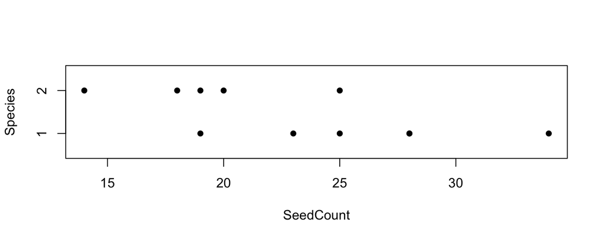

```r
stripchart(SeedCount ~ Species, data=seeds, pch=16,
           ylab="Species", ylim=c(0.5,2.5))
```

## Wilcoxon test in R

```r
wilcox.test(SeedCount ~ Species, data=seeds)
```

```
##
##  Wilcoxon rank sum test with continuity correction
##
## data:  SeedCount by Species
## W = 26, p-value = 0.05358
## alternative hypothesis: true location shift is not equal to 0
```

## Paired Designs

- Sometimes observations occur in pairs:
  - Two observations on the same individual (two days, two sides, before/after…)
  - observing two groups over time
- Examples:
  - subjects occur naturally in pairs, such as identical twins
  - subjects matched in pairs for similar age, sex, profession, disease status, etc (to match extraneous variables)
  - same subject measured on two occasions

## Paired sample t-test

- A combination of two things we already know - two-sample and one sample t-tests (also Confidence Intervals):
  1. Recognize that it is a paired design.
  2. Do hypothesis testing steps like a two independent sample t-test
  3. Do t calculations like a 1-sample t-test but for differences of measurements.

## Example

- Have 12 fruit flies from 6 different lines (**2 of each**) grown in vials at **two different temperatures**.
- After a specified time for development, count the number of bristles on each fly.
- We think that bristle number has approximately a normal distribution, but flies from the same line should have similar bristle numbers.
- We will look at the **difference** in bristle number **between two flies of the same line**.

## Example (continued)

- 6 “blocks” (lines).
- 2 treatments = temperature (cold/warm)
- Have 12 observations but they occur in 6 pairs, so n = 6.

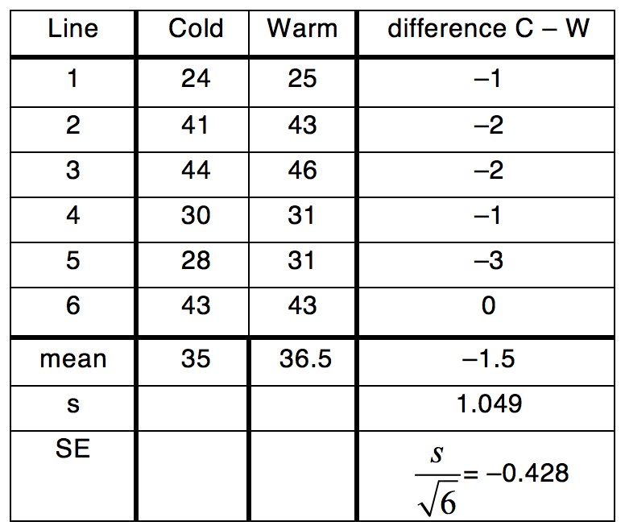

- Does temperature affect the number of bristles on fruit flies?

## Example (continued)

- Let 1 and 2 be the mean bristle number for flies grown at the colder and warmer temperatures, respectively:
  - H\(_0\): \(\mu_1 = \mu_2\) (i.e., \(\mu_1 - \mu_2=0\)): the mean bristle number is the same for both temperatures
  - H\(_A\): \(\mu_1 \neq \mu_2\) (i.e., \(\mu_1 - \mu_2\neq 0\)): the mean bristle number is different at the two temperatures
- Use a non-directional paired sample t-test.
  - Test statistic: \(t_s = \frac{\bar{y}_{diff}}{SE_{diff}}\)
  - Use t-distribution to find p-value.
- Will reject H\(_0\) if p < \(\alpha =\) 0.05, otherwise will not reject H\(_0\).

## Paired sample t-test in R

```r
flies<-read.csv('DataSets2/flytemp.csv')
```

```r
View(flies)
```

```r
t.test(flies$Cold, flies$Warm, paired=TRUE)
```

```
##
##  Paired t-test
##
## data:  flies$Cold and flies$Warm
## t = -3.5032, df = 5, p-value = 0.01722
## alternative hypothesis: true difference in means is not equal to 0
## 95 percent confidence interval:
##  -2.6006574 -0.3993426
## sample estimates:
## mean of the differences
##                    -1.5
```

## Paired tests

- How to know whether to use paired or unpaired t-test to analyze a given data set?
  - Easy: Does each data point in one sample naturally correspond to one specific data point in the other sample? If so, use paired t-test.
- How to know when to use a paired design in your experiment?
  - Harder: Do you expect the extraneous variables to increase variation and want to match on these variables, or pairing is dictated by the problem (e.g. repeated measurements)?
- If so use paired design.

## Assumptions

- Paired-sample t-test is based on the idea that the *differences* are approximately normal, so may want to plot the histogram.
- This will automatically be true if the individual groups are both normally distributed.

## Sign test

- What if the data are not normally distributed?
  - Recall: for two independent samples did Wilcoxon-Mann-Whitney.
- For paired samples we can do the **sign test**.
- Look at the **sign** of the *difference between each pair of observations*.
- If the two treatments are the same, the sign is equally likely to be positive as negative. That is, if we take a pair at random (from the population of pairs), whether the first or second of the pair is larger is like flipping a coin.

## Sign test

- Let \(\pi\) = probability that, for any pair from the population, the first will be larger.
  - H\(_0\): \(\pi\) = 0.5; the two treatments are the same in their effect.
  - H\(_A\): \(\pi\neq\) 0.5 (this is the non-directional alternative): the two treatments are different in their effect.
1. For each pair of observations, note whether y\(_1\)–y\(_2\) is positive (+) or negative (–), that is, + if y\(_1\) is bigger, – if y\(_2\) is bigger
2. count the number of + (= N\(_+\)) and – (= N\(_–\)) (don’t count zeros).
3. test statistic B\(_s\) = larger of N\(_+\) and N\(_–\).
4. Reject H\(_0\) if B\(_s \geq\) critical value.

## Example: skin grafts

- Skin grafts applied to *both sides of body* in 11 recipients.
- One graft has good HLA antigen system match with recipient; the other does not.
- This is paired because we have two observations from each person.
- Observe time to rejection of skin graft (not normally distributed so don’t use t-test.)

## Does a good HLA match increase graft survival time?

- Let \(\pi\) = probability that good HLA match survives longer in any individual
  - H\(_0\): \(\pi\) = 0.5; HLA match and non-match are equally likely to survive longer.
  - H\(_A\): \(\pi >\) 0.5; HLA match is more likely to survive longer (directional alternative).
- Use a sign test.
  - B\(_s\) = N\(_+\) has a binomial distribution (n=11, \(\pi\)= 0.5) under H\(_0\). If non-directional, Bs would be max(N+, N–).
- Test at level \(\alpha\) = 0.05 ; critical value is 9 (from computer).
- Will reject H\(_0\) if B\(_s \geq\) 9; if B\(_s\) < 9 we will not reject.

## Example (continued)

- Data: survival times (days)
- n = 11
- N\(_+\) = 9, N\(_-\) = 2; B\(_s\) = N\(_+\) = 9; B\(_{0.05}\) = 9
- So, reject H\(_0\).
- This study provides evidence (P = 0.033) that a good HLA match survives longer than a poor match.

## Sign test in R

```r
skin <- read.csv('DataSets2/skingraft.csv')
```

```r
## Perform Sign Test using binom.test function (1-sided alternative)
## Input the test statistic (Bs=9), and the number of pairs (n=11)
binom.test(9, 11, alternative="greater")
```

```
##
##  Exact binomial test
##
## data:  9 and 11
## number of successes = 9, number of trials = 11, p-value = 0.03271
## alternative hypothesis: true probability of success is greater than 0.5
## 95 percent confidence interval:
##  0.5299132 1.0000000
## sample estimates:
## probability of success
##              0.8181818
```

## Types of Variables

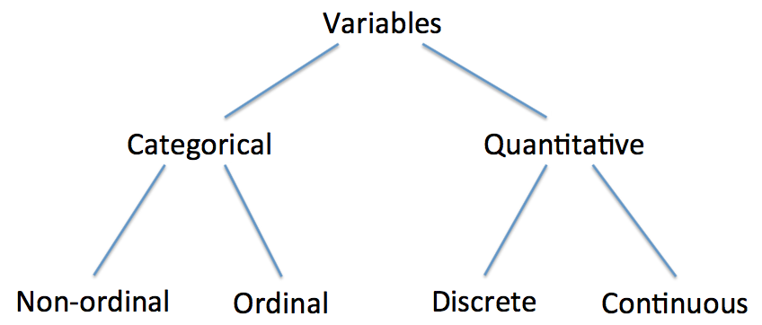

## Types of Variables

- Quantitative:
  - Outcome is a number
  - height or concentration (continuous)
  - number of flowers on a plant (discrete)
- Categorical:
  - outcomes fall into categories we can list
  - peas: round & yellow, round & green, wrinkled & yellow, wrinkled & green (not ordinal)
  - choices on a survey: never, rarely, occasionally, often, always (ordinal)

## Categorical data

- In order to analyze categorical data we start by counting the number of observations in each category.
- If there are only two categories,
  - the number in one category has a binomial distribution (if the observations in the sample are independent).
  - If there are more than two categories,
  - you can focus on one category and group all the others together; still binomial
  - or, more often, you define different \(\pi\)’s for the different categories (\(\pi_1\), \(\pi_2\),…)

## Binomial distribution

- \(\pi\) is the (unknown) probability of “success”, say in category 1.
- n is the number of observations.
- Observe y = # in category 1.
- The proportion in category 1 is \(\hat{\pi} = y/n\).
- y has a binomial (n,\(\pi\)) sampling distribution,
- If n and n(1-\(\pi\)) are not too small, this is close to a normal distribution with mean and SD:  
  \(\mu = n\pi,\ \ \ \ \sigma=\sqrt{n\pi(1-\pi)}\)
- This normal approximation is used both explicitly (for confidence intervals) and implicitly (for testing).

## Chi-squared distribution

- To test hypotheses, we will use a distribution called a \(\chi^2\) distribution (chi-squared).
- Facts about the \(\chi^2\) distribution
  - If you have k random variables \(y_1,...,y_k\) , which are all independent and N(0,1), if you square them all and add them up, the resulting sum has a \(\chi^2_k\) distribution. (“a chi-squared distribution with k degrees of freedom”).
  - \(\chi^2\) random variables only take on positive values.
- We have several different tests which all use the 2 distribution to determine critical values, however, the hypotheses are different.

## Contingency tables

- “2x2” means 2 rows and 2 columns in a table: categorical data with 4 groups that are related in pairs.
- Two main contexts (sometimes blurred):
  - Two independent random samples; one binomial variable observed in each sample
  - One sample; observe two different binomial variables on each sample
- Examples of context 1:
  1. samples are “drug” and “placebo” (or any two treatments); observed variable “improve” or “don’t improve”.
  2. samples are “male” and “female” (any two groups we set up to compare); observed variable “eye color” brown or blue.

## Contingency tables

- Examples of context 2:
  - observe whether people smoke, exercise
  - observe response to drug for patients in a randomized clinical trial. Four Categories, observations in 2x2 table:

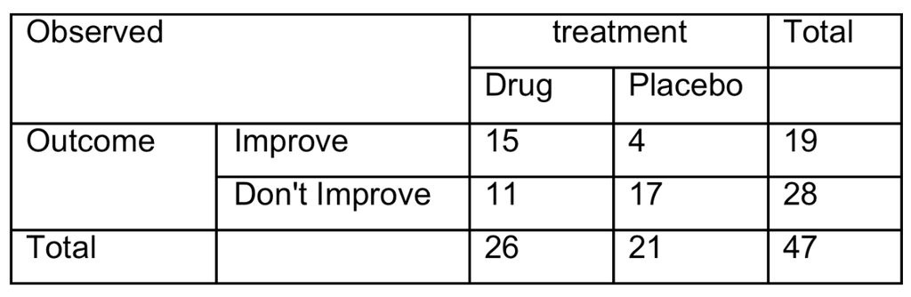

- Test for independence of row and column variables.

## Association testing: example

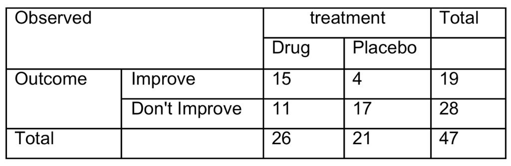

- \(\pi_1\) = probability patient improves if they take the drug
- \(\pi_2\) = probability patient improves if they take the placebo
  - H\(_0\): \(\pi_1 = \pi_2\)
  - H\(_A\): \(\pi_1 \neq \pi_2\) ( or \(\pi_1 > \pi_2\))
- H\(_0\) is that the two probabilities are the same (like \(\mu_1 = \mu_2\) in a t-test), which can be phrased in terms of independence.

## Example (continued)

- H\(_A\) is that the probabilities are different, which can be phrased in terms of a *lack of independence*, which is called *“association”*:
  - \(\hat{\pi}_1\) = # who improve with drug / # who take drug  
    \(\ \ \ \ \) = 15/26 = 0.58
  - \(\hat{\pi}_2\) = # who improve with placebo / # who take placebo  
    \(\ \ \ \ \) = 4/21 = 0.19

## Example (continued)

- What values would we expect under H\(_0\)?
  - Total who improve is 19, so under H\(_0\) estimate 19/47 = 40.4% to be the proportion who improve overall.
  - 26 patients took the drug: under H\(_0\) expect 40.4% of them to improve = (26 \(\times\) 0.404) = 10.5 = (26 \(\times\) 19)/47. Similarly, expect number who improve under placebo to be (21 \(\times\) 19)/47 = 8.5.
  - For the next row, expect (26 \(\times\) 28)/47 = 15.5 don’t improve with drug and (21 \(\times\) 28)/47 = 12.5 don’t improve with placebo.
- Can place these “Expecteds” in a table similar to the observed values. Note that the row and column totals are the same as for observed.

## Example (continued)

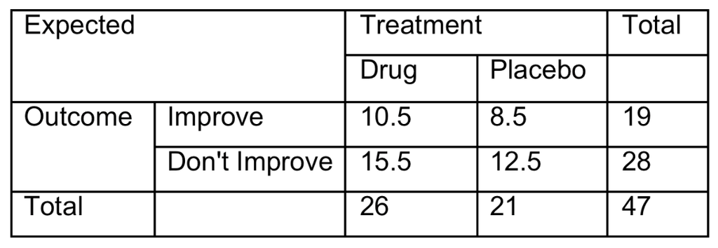

- In general, for each category:
  - E = (row total)(column total)/(grand total)
- This is the common way to organize the E’s and the O’s:

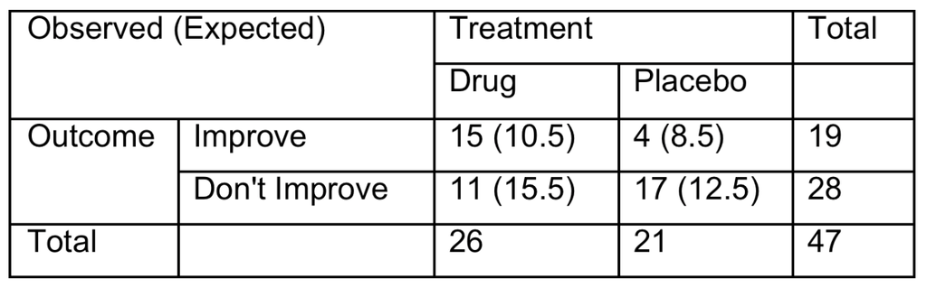

## Example - questions

- Are patients who take the drug more likely to improve than those who take the placebo?
  - \(\pi_1\) = probability patient improves if they take the drug
  - \(\pi_2\) = probability patient improves if they take the placebo
  - H\(_0\): \(\pi_1 = \pi_2\); the probability of improving is the same whether drug or placebo is taken (treatment and outcome are independent)
  - H\(_A\): \(\pi_1 > \pi_2\); the probability of improving is greater if the drug is taken than if the placebo is taken
- This example is directional; if non-directional, H\(_A\): outcome and treatment are not independent.

## Example (continued)

- Use a \(\chi^2\) test of independence
  - \(X^2_s = \sum(O-E)^2/E\) has a \(\chi^2_1\) distribution under H\(_0\).
  - Calculate p-value, and reject H\(_0\) if p < \(\alpha\).
- Since H\(_A\) is directional, must do the following step, but it’s a good idea whether directional or not.
  - \(\hat{\pi_1} = \frac{\#\ who\ improve\ with\ drug} {\#\ who\ take\ drug} = \frac{15}{26} = 0.58\)
  - \(\hat{\pi_2} = \frac{\#\ who\ improve\ with\ placebo} {\#\ who\ take\ placebo} = \frac{4}{21} = 0.19\)
- Check: 0.58 > 0.19, so \(\hat{\pi_1}>\hat{\pi_2}\) is in the same direction as H\(_A\).

## Example (continued)

- \(X^2_s\) = (15-10.5)2/10.5 + (4-8.5)2/8.5  
  \(\ \ \ \ \ \) + (11-15.5)2/15.5 + (17-12.5)2/12.5 = 7.2
- Chi-squared P-value is 0.007 (see next page), so reject H\(_0\).
- This study provides evidence at the \(\alpha\)= 0.01 significance level that the probability of improving is greater if the drug is taken than if the placebo is taken.
- Degrees of freedom: df = 1 for the 2x2 table.
  - In general it is (#rows-1)(#columns-1)
  - \(X^2_s\) has a \(\chi^2_1\) distribution under H\(_0\).

## Chi-square test in R

```r
drugs<-read.csv('DataSets2/drugs.csv')
table(drugs$Treatment, drugs$Response)
```

```
##
##           Improve NoImprove
##   Drug         15        11
##   Placebo       4        17
```

```r
chisq.test(table(drugs$Treatment, drugs$Response), correct=FALSE)
```

```
##
##  Pearson's Chi-squared test
##
## data:  table(drugs$Treatment, drugs$Response)
## X-squared = 7.2037, df = 1, p-value = 0.007275
```

## Chi-square test in R

- Note that we used `correct=FALSE` in the `chisq.test` command: this turns off R’s default continuity correction, which is used to improve the \(\chi^2\) approximation in \(2\times 2\) tables.

```r
chisq.test(table(drugs$Treatment, drugs$Response))
```

```
##
##  Pearson's Chi-squared test with Yates' continuity correction
##
## data:  table(drugs$Treatment, drugs$Response)
## X-squared = 5.6885, df = 1, p-value = 0.01708
```

## What does rejecting H\(_0\) mean?

- Sometimes have to be careful about conclusions in this test. If you reject H\(_0\) with a chi-squared test then that indicates the two variables are **associated**, i.e., not independent; that does not always imply a causal relationship.
- This study provides evidence that patients who take the drug are more likely to improve than patients who take the placebo.
- Here we **controlled** the drug vs. placebo and observed the improvement, so it was reasonable to infer causation. If we had performed a test based on observational data, we could only say that the two variables were associated.

## Analysis of Variance (ANOVA)

- How to analyze data when there are k treatments?
  - Same basic assumptions/limitations as t-test:
  - Each population has a normal distribution
  - Samples are independent and random
  - Want to test hypotheses about the population means \(\mu_i\)
- SD, \(\sigma\), of each population is the same (or similar) so we can use a pooled SE.
- Goal: test hypotheses such as
  - H\(_0\): \(\mu_1 = \mu_2 = \mu_3 = ... = \mu_k\)
  - H\(_A\): at least one of the \(\mu_i\)’s is different than the others.

## ANOVA - The Global F Test

- H\(_0\): \(\mu_1 = \mu_2 = \mu_3 = ... = \mu_k\)
- H\(_A\): at least one of the \(\mu_i\)’s is different than the others.
- To test this hypothesis, we use the test statistic \(F_s\), which is the ratio of the “between-group variation”" to the “within-group variation”.
- Reject H\(_0\) if observed \(F_s\) is “large” (calculate P-value).
- Note: H\(_A\) is non-directional for F-Test, but rejection region is one-tailed.

## Example

- A random sample of 15 healthy young men are split randomly into 3 groups of 5.
- They receive 0, 20, and 40 mg of the drug Paxil per day for a week, respectively.
- Then their serotonin levels are measured to determine whether Paxil affects serotonin levels.

## Hypotheses

- Definitions
  - \(\mu_1\) is the mean serotonin level for men on 0 mg of Paxil.
  - \(\mu_2\) is the mean serotonin level for men on 20 mg of Paxil.
  - \(\mu_3\) is the mean serotonin level for men on 40 mg of Paxil.
- Hypotheses
  - H\(_0\): \(\mu_1 = \mu_1 = \mu_3\) ; mean serotonin levels are the same at all 3 dosage levels (i.e., mean serotonin levels are unaffected by Paxil dose).
  - H\(_A\): The mean serotonin levels of the three groups are not all equal (i.e., serotonin levels are affected by Paxil dose).

## One-way ANOVA in R

```r
paxil<-read.csv('DataSets2/paxil.csv')
View(paxil)
summary(aov(Serotonin ~ as.factor(Dose), data=paxil))
```

```
##                 Df Sum Sq Mean Sq F value  Pr(>F)
## as.factor(Dose)  2  841.9   420.9   8.358 0.00532 **
## Residuals       12  604.3    50.4
## ---
## Signif. codes:  0 '***' 0.001 '**' 0.01 '*' 0.05 '.' 0.1 ' ' 1
```

- p = 0.00532, so reject H\(_0\).
- This study provides evidence that Paxil intake affects serotonin levels in young men.

## How/Why does this work?

- Remember for t-test,
  - take the difference in means: \(\bar{y}_1-\bar{y}_2\)
  - divide by the amount of sampling variation it has: \(SE_{\bar{y}_1-\bar{y}_2}\)
  - if \(\bar{y}_1-\bar{y}_2\) is big compared to the amount of variability expected by chance, \(t_s\) is large; so reject H\(_0\).
- For F-test,
  - take average squared difference between the group means
  - divide it by the amount of sampling variation it has
  - if the between-group variation is large compared to the amount of variability expected by chance, F is large; so reject H\(_0\)

## Why not just do t-tests on each pair?

- You could, but the probability of making at least one Type I error is bigger than just the \(\alpha\) you use for each test because there can be many possible pairs to test.
- For example when we test H\(_0\): \(\mu_1 = \mu_2 = \mu_3\), we are actually testing:
  - H\(_{01}\): \(\mu_1 = \mu_2\)
  - H\(_{02}\): \(\mu_1 = \mu_3\)
  - H\(_{03}\): \(\mu_2 = \mu_3\)
- And we would reject H\(_0\) if any one of H\(_{01}\), H\(_{02}\) or H\(_{03}\) would be rejected by a t-test with prob of Type I error = 0.05 on first test, 0.05 on second test, etc.

## Why not just do t-tests on each pair?

- The more tests you do, the more likely you are to make at least one mistake. (With k > 7 you would expect to make at least one mistake).
- Plus, the tests are not independent so it’s not even easy to decide what the true Type I error probability is.
- Also, ANOVA lets you get at more complicated patterns.
- So, if you don’t reject H\(_0\), stop. The data provide no evidence in favor of H\(_A\).

## Post-hoc testing

- You can perform additional tests to determine which means are different:
- Use the `TukeyHSD` function in R:

```r
TukeyHSD(aov(Serotonin ~ as.factor(Dose), data=paxil))
```

```
##   Tukey multiple comparisons of means
##     95% family-wise confidence level
##
## Fit: aov(formula = Serotonin ~ as.factor(Dose), data = paxil)
##
## $`as.factor(Dose)`
##         diff        lwr      upr     p adj
## 20-0  11.678 -0.2961563 23.65216 0.0561323
## 40-0  18.098  6.1238437 30.07216 0.0043776
## 40-20  6.420 -5.5541563 18.39416 0.3571044
```

## Post-hoc testing

- There is a significant difference in mean serotonin levels between men receiving a 0mg dose of Paxil, and those receiving a 40mg dose.

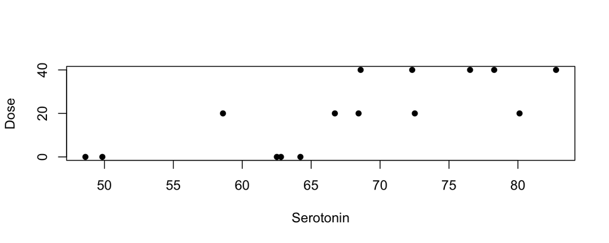

```r
stripchart(Serotonin ~ as.factor(Dose), data=paxil, pch=16, ylab="Dose")
```

## Relationships between quantitative variables

- Often interested in the relationship between two quantitative variables.
- Need methods for:
  - data display
  - describing the relationship

## Relationship between variables

- As in the contingency table data, this may be
  - one random sample; observe two quantities
  - one of the variables may be controlled (e.g. dose)
- Examples
  - X = concentration, Y = rate of reaction
  - X = dose, Y = response
  - X = weight, Y = height
  - X = root extension, Y = carbon allocation
  - X = midterm 1 score, Y = midterm 2 score
- If the experimenter controls one of the variables, that is usually labeled X, and the “response” is Y.

## Heroin again

- For each cadaver blood taken from heart and from peripheral organs.
- Questions of interest:
  - What is the relationship between the two concentrations?
  - Can we use the heart concentration to predict the peripheral concentration?

## Load heroin data

```r
heroin <- read.csv('DataSets2/heroin-regression.csv')
head(heroin)
View(heroin)
```

```
##   Heart Periphery
## 1    67       161
## 2   110       213
## 3    45        87
## 4    96       150
## 5    80       108
## 6   103       145
```

## Scatterplot

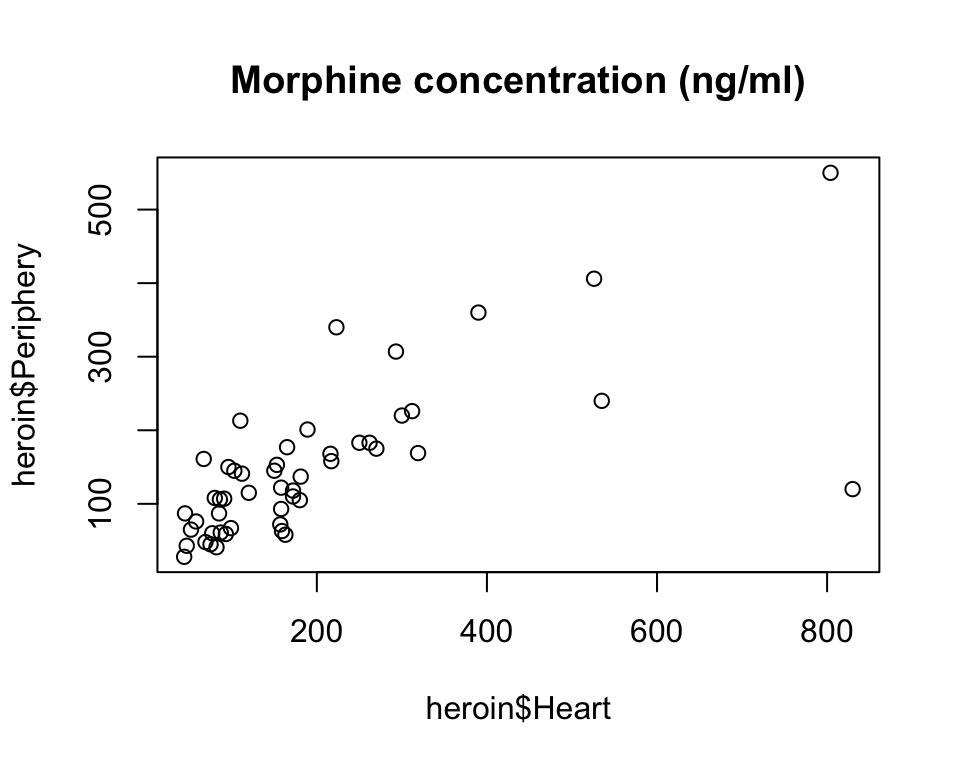

```r
plot(heroin$Heart, heroin$Periphery,
     main="Morphine concentration (ng/ml)")
```

## “Line of best fit”

Fit any line: how good is it?

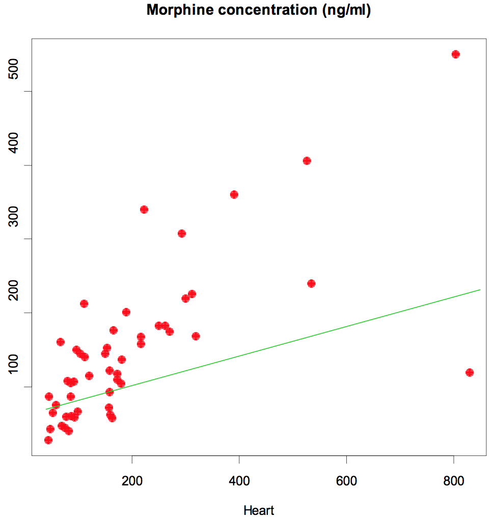

## “Line of best fit”

Calculate the distance from each point to the line, square them, and add them all up.

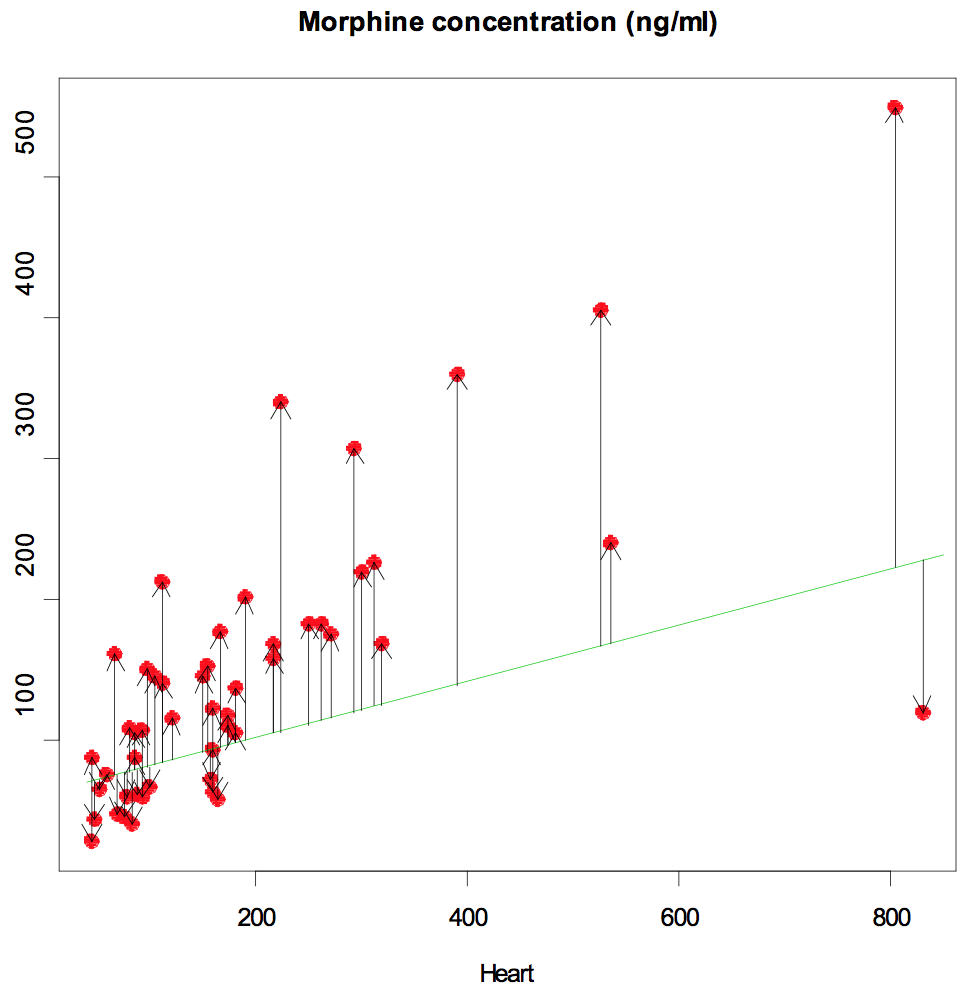

## “Line of best fit”

- *Peripheral conc. = 65 + 0.43 Heart conc.*

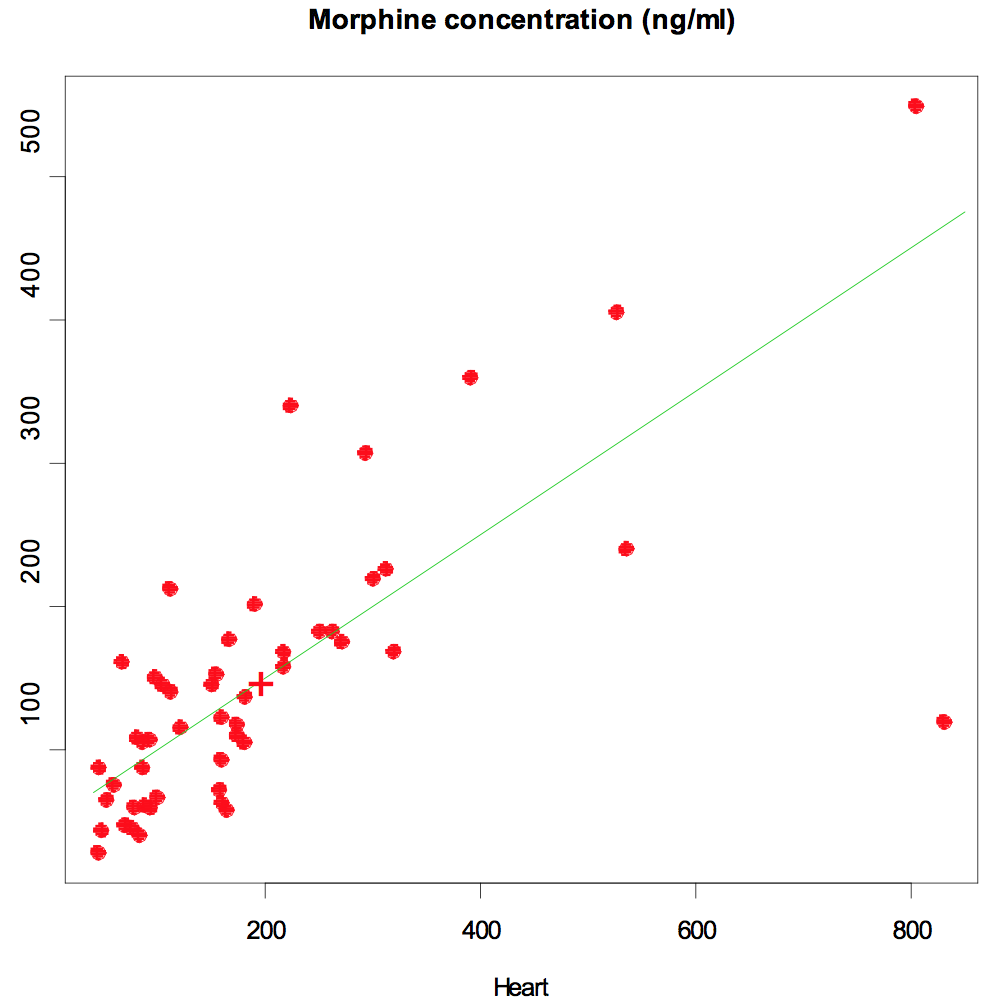

- Line of best fit minimizes these “sums of squared errors”.

## Linear Regression

- A way to look at the relationship between continuous variables
- Back to quantitative data with assumed normal distributions
- Conceptually related to both ANOVA and contingency tables
- “Finding a straight line” through the data
- Data: pairs of observations (X, Y), so observe:
  - (x\(_1\), y\(_1\)), (x\(_2\), y\(_2\)),…, (x\(_n\), y\(_n\))

## What does “best” mean?

- For each observed value of x there is a value of y predicted by the straight line, which we write as

\(\hat{y} = b_0 + b_1 x\)

- This is usually not exactly the same as the observed y for that x.
- Compare the actual vs. predicted y; difference is called residual:
- Residual = \(y\) - \(\hat{y}\) (one for each pair of observations, i.e., n residuals)

## Regression in R

```r
summary(lm(Heart ~ Periphery, data=heroin))
```

```
##
## Call:
## lm(formula = Heart ~ Periphery, data = heroin)
##
## Residuals:
##     Min      1Q  Median      3Q     Max
## -196.95  -54.70   -5.40   25.11  668.61
##
## Coefficients:
##             Estimate Std. Error t value Pr(>|t|)
## (Intercept)  20.3604    30.3705   0.670    0.506
## Periphery     1.1753     0.1699   6.916  9.9e-09 ***
## ---
## Signif. codes:  0 '***' 0.001 '**' 0.01 '*' 0.05 '.' 0.1 ' ' 1
##
## Residual standard error: 121.4 on 48 degrees of freedom
## Multiple R-squared:  0.4991, Adjusted R-squared:  0.4887
## F-statistic: 47.83 on 1 and 48 DF,  p-value: 9.897e-09
```

## Regression output

- Coefficients are the intercept and slope of the regression line.
- Significance of the slope means that there is a linear relationship between the variables.

```r
summary(lm(Heart ~ Periphery, data=heroin))$coefficients
```

```
##              Estimate Std. Error   t value     Pr(>|t|)
## (Intercept) 20.360409 30.3705099 0.6704006 5.058153e-01
## Periphery    1.175255  0.1699363 6.9158543 9.896584e-09
```

## Aside - log transformation

- The relationship between the Heart and Periphery variables is more linear when each variable is log transformed.

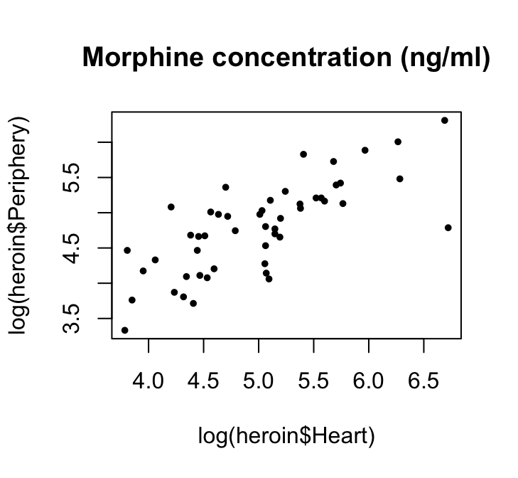

```r
plot(log(heroin$Heart), log(heroin$Periphery), pch=20, cex=0.8,
     main="Morphine concentration (ng/ml)")
```

## Correlation Coefficient

- The correlation coefficient, \(\rho\), measures the strength of linear association between two normally distributed variables.
- r = \(\hat{\rho}\) has the same sign as the slope of the regression model.
- It is always between -1 and +1 and r has no units.
- It will be 1 only if the data points are exactly on a straight line so that all the residuals are 0.
- It will be 0 when there is no linear relationship between X and Y.
- A value “close” to 1 indicates a “tight” linear relationship between X and Y.

## Correlation

- If r is large in magnitude (close to 1) we say X and Y are highly “correlated”.
  - “Negatively correlated” when r is negative,
  - “Positively correlated” when r is positive.
- If r = 0 there is no linear relationship; we say X and Y are “uncorrelated” (Note: uncorrelated is not the same thing as independent!)
- The word “uncorrelated” is also used to describe data with small but nonzero values of r.

## Testing H\(_0\): \(\rho\) = 0

- Test H\(_0\) the same way (questions, distributions, conclusions) as above:
  - Is there a linear relationship between Y and X?
- Let \(\rho\) be the correlation coefficient between X and Y for the population.
  - H\(_0\): \(\rho=0\) There is no linear relationship between Y and X.
  - H\(_A\): \(\rho\neq0\) There is a linear relationship between Y and X. (or H\(_A\) could be directional, e.g., H\(_A\): \(\rho\) > 0).

## Correlation in R

- Default is “Pearson”: for normally distributed variables

```r
cor(heroin$Heart, heroin$Periphery)
```

```
## [1] 0.7064758
```

- “Spearman” is a rank-based approach (doesn’t require normality).

```r
cor(heroin$Heart, heroin$Periphery, method='spearman')
```

```
## [1] 0.7625885
```

## Test for significance

```r
cor.test(heroin$Heart, heroin$Periphery)
```

```
##
##  Pearson's product-moment correlation
##
## data:  heroin$Heart and heroin$Periphery
## t = 6.9159, df = 48, p-value = 9.897e-09
## alternative hypothesis: true correlation is not equal to 0
## 95 percent confidence interval:
##  0.5329257 0.8229865
## sample estimates:
##       cor
## 0.7064758
```

## Assignment: R Markdown

- RStudio provides a framework for producing documents within R: R Markdown
- R Markdown uses a simple syntax to produce documents containing:
  - comments
  - code
  - output
- By deafult, running an R Markdown (.Rmd) file will produce HTML output, although other output formats can be used.
- See the website below for more details, and click the “Get Started” link to get a video overview.

http://rmarkdown.rstudio.com/

## Creating an R Markdown document

- In RStudio, select the ‘New File’ then ‘R Markdown…’ from the ‘File’ menu.
- Choose ‘Document’ and give it a name (leave the output format as “HTML”), then click ‘OK’.
- This creates a basic R Markdown document conating some sample code:
  - the top of the file contains some basic information
  - blocks of R code have ```{r} in front, and ``` after: these are run when you click “Knit” (see next slide), and the output appears in the HTML file
  - everything else in the file is treated as text to be displayed

## Creating an R Markdown document

- Various text effects can be achieved using markdown syntax (e.g., “##” for headings): see the link below for (many) more options.
- Clicking the “Knit” button in RStudio (above your code window) will run the code, and open a built-in browser that displays the processed document as rendered HTML.
- This file is saved in a folder within your working directory, and can be opened in any web browser, exported to other formats etc.
- A big advantage of R Mardown is *reproducibility* - anyone with the .Rmd file and associated data can *exactly* reproduce the results in the document.

http://rmarkdown.rstudio.com/authoring_basics.html